# Cartola PFC - Análise de clusters no Cartola FC. Goleiros, Zagueiros e Laterais

Henrique Gomide, Ph.D.

10/09/2019

Direto ao ponto. Vamos analisar jogadores de defesa do Cartola FC dando sequência a [apresentação da técnica e análise dos atacantes](https://medium.com/ensina-ai/cartola-pfc-analisando-os-atacantes-do-primeiro-turno-com-affinity-propagation-89df6304b4e4) e a [análise dos meias](https://medium.com/ensina-ai/cartola-pfc-quais-meias-escalar-no-cartola-ofensivos-ou-defensivos-abe8d7db121d).

Os dados são obtidos da sempre atualizada base de dados com as médias acumuladas no repositório caRtola.

De maneira geral, seguiremos os seguintes procedimentos para análise dos dados: 1) limpeza dos dados; 2) [escalonamento multidimensional](https://datascience.insper.edu.br/escalonamento-multidimensional.html) e 3) [affinity propagation](https://science.sciencemag.org/content/315/5814/972.full).

Uma breve descrição do banco de dados. Temos apelido, código do time, e as médias acumuladas para quase todos os scouts do Cartola FC. Além disso, temos a média acumulada em casa/fora, a diferença entre as médias casa/fora padronizadas (diff_home_away_s), número de jogos na temporada entre outros.

Antes de iniciar de aplicar as técnicas de agrupamento, vamos preparar um pouco o banco de dados para conduzir as análises. A limpeza inclui: selecionar jogadores por posição com um mínimo de jogos. Em algumas posições tiraremos jogadores que possuem média baixa na temporada.

```r
data_url <- "https://raw.githubusercontent.com/henriquepgomide/caRtola/master/data/2019/2019-medias-jogadores.csv"
cartola <- read.csv(data_url,
                    stringsAsFactors = FALSE)
glimpse(cartola)
```

```
## Observations: 640
## Variables: 26
## $ player_slug               <chr> "paulo-andre", "evandro", "betao", "ra…
## $ player_id                 <int> 37604, 37614, 37646, 37655, 37656, 376…
## $ player_nickname           <chr> "Paulo André", "Evandro", "Betão", "Ra…
## $ player_team               <int> 293, 277, 314, 290, 283, 275, 293, 341…
## $ player_position           <chr> "zag", "mei", "zag", "ata", "gol", "za…
## $ price_cartoletas          <dbl> 3.91, 3.95, 3.64, 3.57, 9.29, 6.97, 7.…
## $ score_mean                <dbl> 0.7250000, 1.0428571, 2.1450000, 0.355…
## $ score_no_cleansheets_mean <dbl> -0.5250000, 1.0428571, 0.8950000, 0.35…
## $ diff_home_away_s          <dbl> -0.10130507, 0.71530267, -0.79498911, …
## $ n_games                   <int> 4, 7, 20, 9, 20, 4, 5, 11, 21, 18, 10,…
## $ score_mean_home           <dbl> 4.500000, 2.233333, 2.177778, -0.25000…
## $ score_mean_away           <dbl> -0.5333333, 0.1500000, 2.1181818, 0.84…
## $ shots_x_mean              <dbl> 0.0000000, 0.2857143, 0.1000000, 0.555…
## $ fouls_mean                <dbl> 1.5000000, 1.8571429, 1.0000000, 2.111…
## $ RB_mean                   <dbl> 0.50000000, 0.71428571, 1.35000000, 0.…
## $ PE_mean                   <dbl> 0.5000000, 1.2857143, 1.9500000, 0.777…
## $ A_mean                    <dbl> 0.00000000, 0.28571429, 0.00000000, 0.…
## $ I_mean                    <dbl> 0.00000000, 0.00000000, 0.00000000, 0.…
## $ FS_mean                   <dbl> 0.0000000, 0.4285714, 0.9500000, 1.000…
## $ FF_mean                   <dbl> 0.00000000, 0.14285714, 0.10000000, 0.…
## $ G_mean                    <dbl> 0.00000000, 0.00000000, 0.00000000, 0.…
## $ DD_mean                   <dbl> 0.000000, 0.000000, 0.000000, 0.000000…
## $ DP_mean                   <dbl> 0.0, 0.0, 0.0, 0.0, 0.1, 0.0, 0.0, 0.0…
## $ status                    <chr> "Provável", "Suspenso", "Provável", "P…
## $ price_diff                <dbl> 0.11, -1.29, -0.51, 0.86, -0.22, 0.56,…
## $ last_points               <dbl> 1.7, -2.8, -1.6, 2.9, -2.3, 4.5, 17.7,…
```

## Goleiros

```r
gol <-
  cartola %>%
  filter(n_games >= 08 &
           player_position %in% c("gol"))
```

### Quais scouts estão associados com melhores médias?

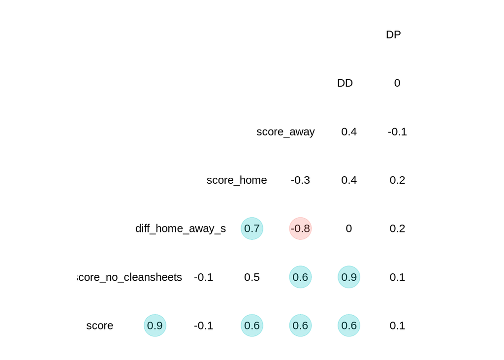

```r
# Selecionar variáveis de interesse para análise de agrupamento
gol_nickname <- gol$player_nickname
gol <- gol[, c("score_mean", "score_no_cleansheets_mean",
               "diff_home_away_s", "score_mean_home",
               "score_mean_away", "DD_mean", "DP_mean")]
names(gol) <- gsub("_mean", "", names(gol))
gol <- dummify(gol)


# Plotar matriz de correlação
ggcorr(gol, geom = "blank", label = TRUE, hjust = 0.75) +
  geom_point(size = 10, aes(color = coefficient > 0, alpha = abs(coefficient) > 0.5)) +
  scale_alpha_manual(values = c("TRUE" = 0.25, "FALSE" = 0)) +
  guides(color = FALSE, alpha = FALSE)
```

Esta análise de correlação pode nos ajudar a começar a entender quais atributos estão mais associados ao desempenho dos goleiros. Defesas difíceis devem ser olhadas para escalar goleiros. Estão correlacionadas de maneira moderada com o a média acumulada de pontos. Não parece haver diferença entre pontuação médias dentro e fora quando descontado o saldo de gols.

### Análise de agrupamentos

```r
# Criar matriz com escalonamento multidimensional
mds <-
  gol %>%
  dist() %>%
  cmdscale() %>%
  as_tibble(.name_repair = "unique")
colnames(mds) <- c("Dim.1", "Dim.2")

# Preparar dados para algoritmo de propagação por afinidade.
datacluster <- dist(gol)
datacluster <- as.matrix(datacluster)
apmodel     <- apcluster(negDistMat(r = 2), datacluster)
mds$cluster <- as.factor(apcluster::labels(apmodel, type = "enum"))
gol$cluster <- as.factor(apcluster::labels(apmodel, type = "enum"))
```

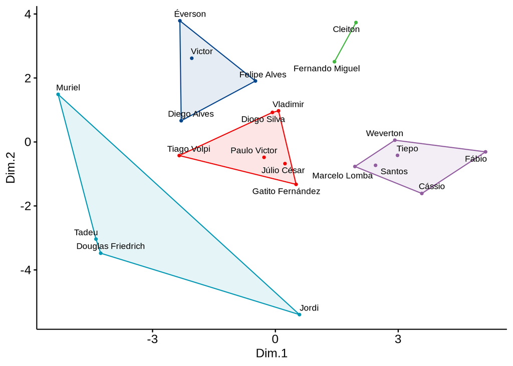

```r
# Plotar scatter
ggscatter(mds,
          x = "Dim.1",
          y = "Dim.2",
          label = gol_nickname,
          color = "cluster",
          palette = "lancet",
          font.label = c(9, "plain", "black"),
          size = 1,
          ellipse = TRUE,
          ellipse.type = "convex",
          repel = TRUE) +
  theme(legend.position = "none")
```

Ao analisar a figura acima, que os goleiros podem ser agrupados em 5 clusters. No cluster azul escuro temos Éverson, Victor, Felipe Alves e Diego Alves, goleiros que têm como característica médias fora de casa melhores que dentro de casa. Embora Diego Alves possua média de pontos melhor que os demais, esta média depende do saldo de gols do Flamengo.

O segundo cluster que merece nossa atenção é o dos goleiros de primeira ordem, que são: Jordi, Douglas Friedrich, Tadeu e Muriel. Eles compartilham algumas métricas em comum tais como boas médias fora de casa. Também são goleiros que apresentam médias maiores de defesas difíceis e portanto médias quando descontados os saldo de gols. Jordi se desgarra do grupo por ser único goleiro que possui média em casa maior que fora de casa.

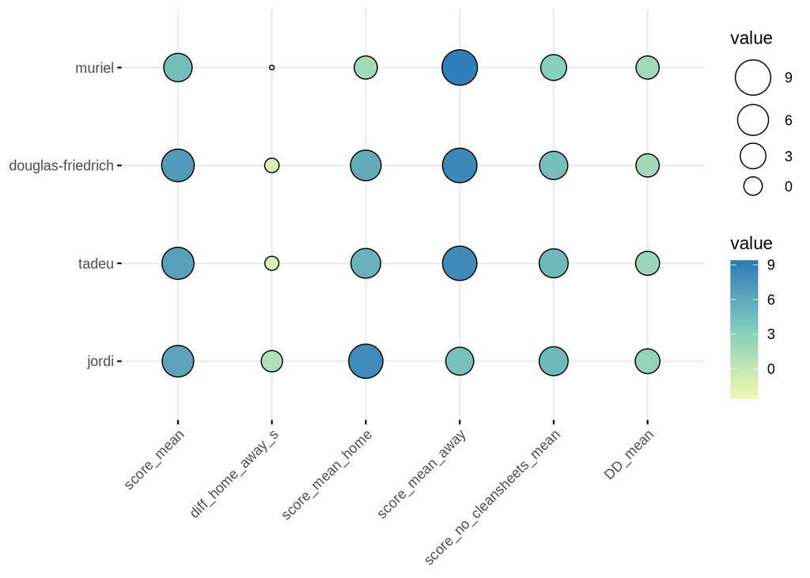

```r
tb <-
  cartola %>%
  filter(player_slug %in% c("jordi", "tadeu", "douglas-friedrich", "muriel")) %>%
  select(player_slug, score_mean, diff_home_away_s,
         score_mean_home, score_mean_away, score_no_cleansheets_mean,
         DD_mean)
plot <- tb[, -1]
row.names(plot) <- tb$player_slug

ggballoonplot(plot, fill = "value") +
  gradient_fill(c(brewer.pal(n = 3, name = "YlGnBu")))
```

Por fim, vamos analisar o terceiro cluster. Nele estão Fábio, Weverton, Tiepo, Marcelo Lomba, Santos e Cássio. O que estes goleiros têm em comum? São goleiros caseiros com pontuação melhor em casa do que fora. Além disso, possuem pontuação que vêm do saldo de gols e não necessariamente da produção em defesas difíceis. Se Santos foi convocado, com certeza não foi pelas estatísticas do campeonato brasileiro.

## Laterais

Hora de analisar laterais e tentar achar padrões para maximizarmos retorno sobre investimento.

```r
defenders <-
  cartola %>%
  filter(n_games >= 8 &
           player_position %in% c("lat")) %>%
  filter(score_no_cleansheets_mean > quantile(score_no_cleansheets_mean,
                                              probs = .3))
```

Vamos começar com uma matriz de correlação para facilitar nossa interpretação.

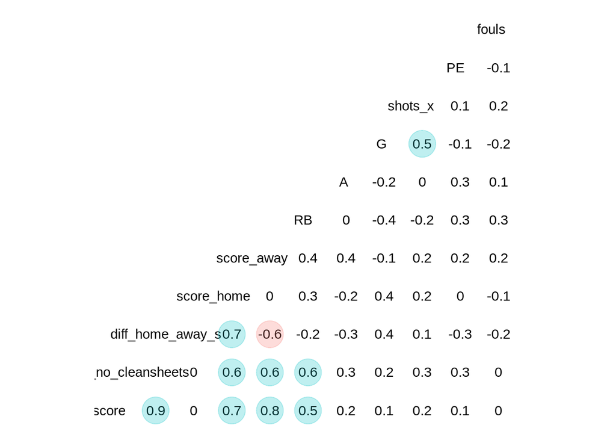

```r
# Selecionar variáveis de interesse para análise de agrupamento
def_nickname <- defenders$player_nickname
defenders    <- defenders[, c("score_mean", "score_no_cleansheets_mean",
               "diff_home_away_s", "score_mean_home",
               "score_mean_away", "RB_mean", "A_mean",
               "G_mean", "shots_x_mean", "PE_mean", "fouls_mean")]
names(defenders) <- gsub("_mean", "", names(defenders))
defenders <- dummify(defenders)


# Plotar matriz de correlação
ggcorr(defenders, geom = "blank", label = TRUE, hjust = 0.75) +
  geom_point(size = 10, aes(color = coefficient > 0, alpha = abs(coefficient) > 0.5)) +
  scale_alpha_manual(values = c("TRUE" = 0.25, "FALSE" = 0)) +
  guides(color = FALSE, alpha = FALSE)
```

### Análise de agrupamentos

```r
# Criar matriz com escalonamento multidimensional
mds <-
  defenders %>%
  dist() %>%
  cmdscale() %>%
  as_tibble(.name_repair = "unique")
colnames(mds) <- c("Dim.1", "Dim.2")

# Preparar dados para algoritmo de propagação por afinidade.
datacluster <- dist(defenders)
datacluster <- as.matrix(datacluster)
apmodel     <- apcluster(negDistMat(r = 2), datacluster)
mds$cluster <- as.factor(apcluster::labels(apmodel, type = "enum"))
defenders$cluster <- as.factor(apcluster::labels(apmodel, type = "enum"))
```

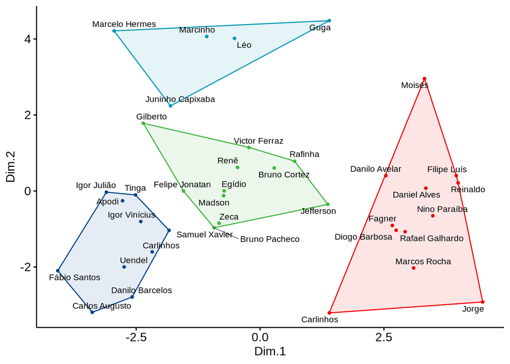

```r
# Plotar scatter
ggscatter(mds,
          x = "Dim.1",
          y = "Dim.2",
          label = def_nickname,
          color = "cluster",
          palette = "lancet",
          font.label = c(9, "plain", "black"),
          size = 1,
          ellipse = TRUE,
          ellipse.type = "convex",
          repel = TRUE) +
  theme(legend.position = "none")
```

Temos quatro agrupamentos de laterais. Vamos olhar para o que mais nos interessa, laterais de primeiro escalação, identificados em vermelho. Embora possuam boa pontuação média, este grupo possui jogadores com características distintas. Jorge, o melhor lateral é o cão chupando manga fora de casa; enquanto Moisés apresenta pontuação fora de casa superior do que quando joga em casa. Alguns laterais possuem estatísticas muito semelhantes como Fagner, Diogo Barbosa e Rafael Galhardo, jogadores que dependem de SG para terem a pontuação. Reinaldo e Filipe Luis possuem características muito semelhantes.

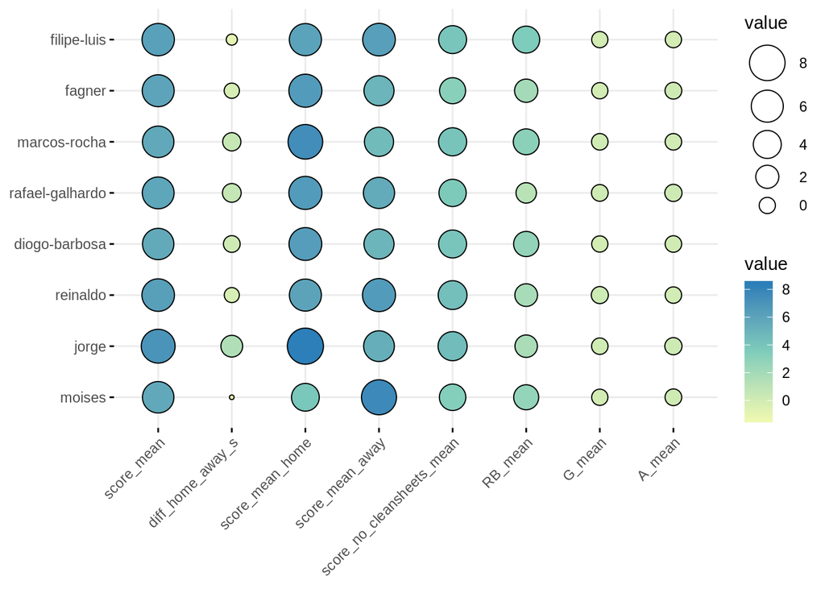

```r
tb <-
  cartola %>%
  filter(player_position == "lat") %>%
  filter(player_slug %in% c("moises", "jorge", "filipe-luis", "reinaldo",
                            "fagner", "diogo-barbosa", "marcos-rocha",
                            "rafael-galhardo")) %>%
  select(player_slug, score_mean, diff_home_away_s,
         score_mean_home, score_mean_away, score_no_cleansheets_mean,
         RB_mean, G_mean, A_mean)
plot <- tb[, -1]
row.names(plot) <- tb$player_slug

ggballoonplot(plot, fill = "value") +
  gradient_fill(c(brewer.pal(n = 3, name = "YlGnBu")))
```

Já no grupo superior (azul claro), temos jogadores que apresentam médias fora de casa muito maiores do que em casa. No grupo verde, jogadores que não possuem tanta flutuação dentro e fora de casa.

## Zagueiros

Pronto. Chegou a hora de analisar os defensores. Seguiremos com o mesmo código e analisaremos a matriz de correlação.

```r
defenders <-
  cartola %>%
  filter(n_games >= 8 &
           player_position %in% c("zag")) %>%
  filter(score_no_cleansheets_mean > quantile(score_no_cleansheets_mean,
                                              probs = .3))
```

Vamos começar com uma matriz de correlação para facilitar nossa interpretação.

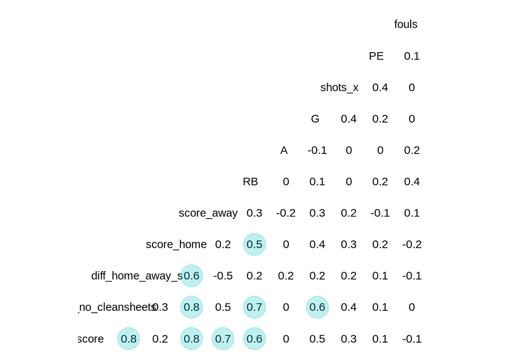

```r
# Selecionar variáveis de interesse para análise de agrupamento
def_nickname <- defenders$player_nickname
defenders    <- defenders[, c("score_mean", "score_no_cleansheets_mean",
               "diff_home_away_s", "score_mean_home",
               "score_mean_away", "RB_mean", "A_mean",
               "G_mean", "shots_x_mean", "PE_mean", "fouls_mean")]
names(defenders) <- gsub("_mean", "", names(defenders))
defenders <- dummify(defenders)


# Plotar matriz de correlação
ggcorr(defenders, geom = "blank", label = TRUE, hjust = 0.75) +
  geom_point(size = 10, aes(color = coefficient > 0, alpha = abs(coefficient) > 0.5)) +
  scale_alpha_manual(values = c("TRUE" = 0.25, "FALSE" = 0)) +
  guides(color = FALSE, alpha = FALSE)
```

Não há grande surpresa na escalação dos zagueiros. Pontuações, desconsiderando o saldo de gols, estão associadas fortemente com roubadas de bola e com a pontuação dentro de casa. Outra curiosidade é o fato da média de gols estar muito mais associada do que com os laterais.

### Análise de agrupamentos

```r
# Criar matriz com escalonamento multidimensional
mds <-
  defenders %>%
  dist() %>%
  cmdscale() %>%
  as_tibble(.name_repair = "unique")
colnames(mds) <- c("Dim.1", "Dim.2")

# Preparar dados para algoritmo de propagação por afinidade.
datacluster <- dist(defenders)
datacluster <- as.matrix(datacluster)
apmodel     <- apcluster(negDistMat(r = 2), datacluster)
mds$cluster <- as.factor(apcluster::labels(apmodel, type = "enum"))
defenders$cluster <- as.factor(apcluster::labels(apmodel, type = "enum"))
```

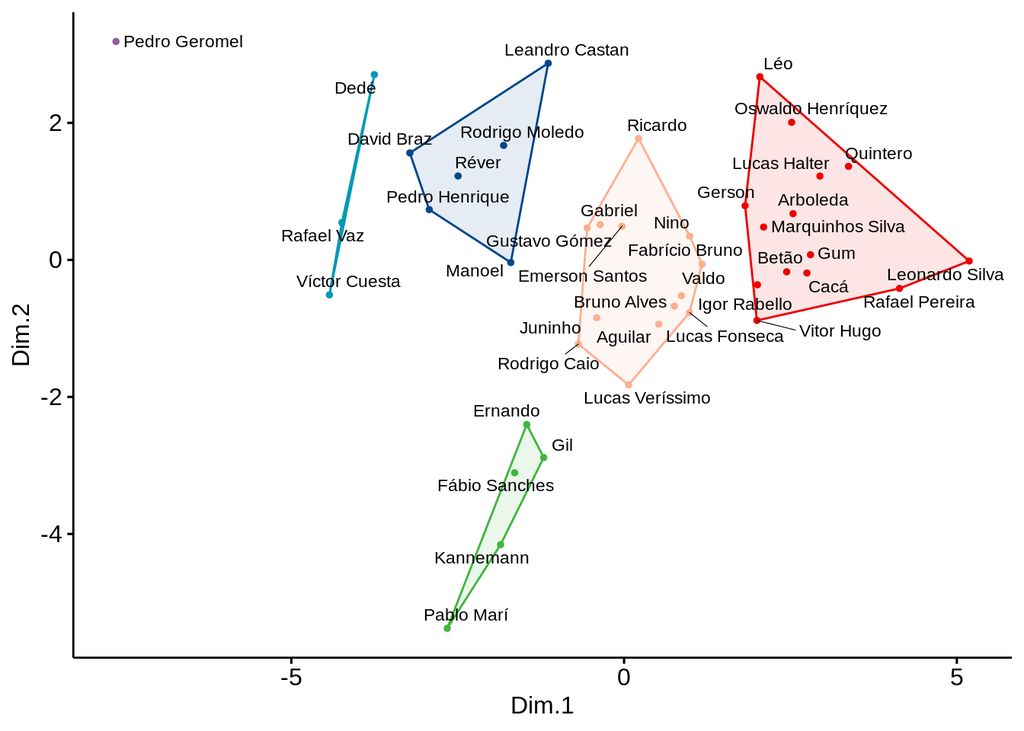

```r
# Plotar scatter
ggscatter(mds,
          x = "Dim.1",
          y = "Dim.2",
          label = def_nickname,
          color = "cluster",
          palette = "lancet",
          font.label = c(9, "plain", "black"),
          size = 1,
          ellipse = TRUE,
          ellipse.type = "convex",
          repel = TRUE) +
  theme(legend.position = "none")
```

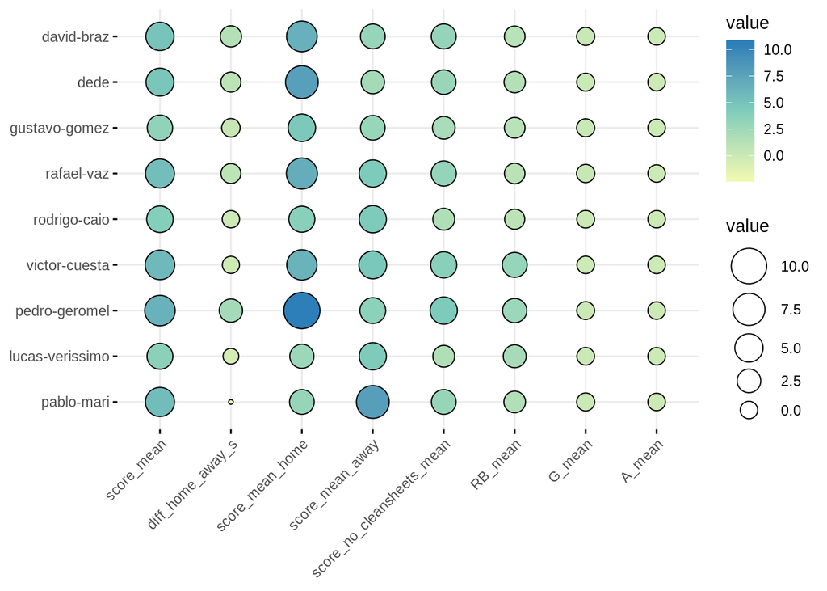

```r
tb <-
  cartola %>%
  filter(player_position == "zag") %>%
  filter(player_slug %in% c("pedro-geromel", "dede", "rafael-vaz",
                            "victor-cuesta", "david-braz", "pablo-mari",
                            "gustavo-gomez", "rodrigo-caio", "lucas-verissimo")) %>%
  select(player_slug, score_mean, diff_home_away_s,
         score_mean_home, score_mean_away, score_no_cleansheets_mean,
         RB_mean, G_mean, A_mean)
plot <- tb[, -1]
row.names(plot) <- tb$player_slug

ggballoonplot(plot, fill = "value") +
  gradient_fill(c(brewer.pal(n = 3, name = "YlGnBu")))
```

## Conclusões

Vamos as conclusões. Conseguimos através da análise de agrupamentos identificar jogadores de defesa com características semelhantes, o que pode ser útil na escalação.

Quanto aos goleiros, percebemos que o processo de escalação deve envolver a análise das médias de defesas difíceis e da análise das chances de saldo de gols. Num futuro tutorial iremos analisar o impacto de um determinado goleiro enfrentar times que chutam muito a gol.

Quanto aos laterais, conseguimos também classificar os grupos com maior média e que possuem diferenças entre ter desempenho em casa e fora. A média acumulada de roubada de bola também precisa ser olhada - não se esqueça de escolher aqueles que também têm alguma chance de fazer gols e assistências.

Por fim, mas não por último, temos os zagueiros. Percebemos que Pedro Geromel está acima do bem e do mal e há grupos distintos de zagueiros; alguns caseiros e outros que jogam melhor fora de casa. Saber destes detalhes pode ser útil para tomar decisões para escalar os jogadores.

Quer ter acesso a estas análises durante todo o campeonato? Mande um e-mail para: cartolapfclube@gmail.com

H.G.